# Data_Visualization_assignment (2)

```python
from google.colab import files

print("Please upload the assignment data file(s):")
uploaded = files.upload()

for filename, data in uploaded.items():
  print(f"Uploaded file '{filename}'")
  with open(filename, 'wb') as f:
    f.write(data)
  print(f"Saved file '{filename}' to Colab environment.")
```

```
Please upload the assignment data file(s):
```

Upload widget is only available when the cell has been executed in the current browser session. Please rerun this cell to enable.

```
Saving London_airbnb.csv to London_airbnb.csv
Uploaded file 'London_airbnb.csv'
Saved file 'London_airbnb.csv' to Colab environment.
```

```python
import pandas as pd

filename = list(uploaded.keys())[0]

try:
  df = pd.read_csv(filename)
  print("\nDataFrame head:")
  print(df.head())
except FileNotFoundError:
  print(f"Error: The file '{filename}' was not found after upload.")
except Exception as e:
  print(f"An error occurred while reading the file: {e}")
```

```
DataFrame head:
       id                                  name  host_id host_name  \
0  106332      Lovely large room, Bethnal Green   264345     Susie
1   13913   Holiday London DB Room Let-on going    54730     Alina
2  284532   COSY STUDIO-FLAT WITH A GREAT  VIEW  1481412      Luca
3  107048  A Luxury Studio Suite in Clerkenwell   259088     Simon
4  284603   Notting Hill church stay in Heaven!  1481851     Tania

   neighbourhood_group           neighbourhood  latitude  longitude  \
0                  NaN           Tower Hamlets  51.52874   -0.05396
1                  NaN               Islington  51.56861   -0.11270
2                  NaN           Tower Hamlets  51.52851   -0.07426
3                  NaN               Islington  51.52478   -0.10484
4                  NaN  Kensington and Chelsea  51.51464   -0.20004

```

[output cut: 20 more lines]

```python
print("\nDataFrame Info:")
df.info()

print("\nDataFrame Description:")
print(df.describe())

print("\nNumber of unique values per column:")
print(df.nunique())

print("\nMissing values per column:")
print(df.isnull().sum())

print("\nInferred Business Context:")
print("Look at the column names (df.columns) and the head of the dataframe (df.head())")
print("Common columns like 'CustomerID', 'ProductID', 'Date', 'Amount', 'Category', etc.")
print("can suggest business areas like Sales, Marketing, Finance, etc.")
print("Observing the values in these columns will help understand the type of data (e.g., transactions, customer demographics, product information).")
print("\nColumn Names:")
df.columns
```

```
DataFrame Info:
<class 'pandas.core.frame.DataFrame'>
RangeIndex: 69351 entries, 0 to 69350
Data columns (total 18 columns):
 #   Column                          Non-Null Count  Dtype
---  ------                          --------------  -----
 0   id                              69351 non-null  int64
 1   name                            69330 non-null  object
 2   host_id                         69351 non-null  int64
 3   host_name                       69346 non-null  object
 4   neighbourhood_group             0 non-null      float64
 5   neighbourhood                   69351 non-null  object
 6   latitude                        69351 non-null  float64
 7   longitude                       69351 non-null  float64
 8   room_type                       69351 non-null  object
 9   price                           69351 non-null  int64
 10  minimum_nights                  69351 non-null  int64
 11  number_of_reviews               69351 non-null  int64
 12  last_review                     52571 non-null  object
 13  reviews_per_month               52571 non-null  float64
 14  calculated_host_listings_count  69351 non-null  int64
 15  availability_365                69351 non-null  int64
 16  number_of_reviews_ltm           69351 non-null  int64
 17  license                         0 non-null      float64
dtypes: float64(5), int64(8), object(5)
memory usage: 9.5+ MB

DataFrame Description:
                 id       host_id  neighbourhood_group      latitude  \
count  6.935100e+04  6.935100e+04                  0.0  69351.000000
mean   1.373703e+17  1.242124e+08                  NaN     51.509544
std    2.651479e+17  1.377104e+08                  NaN      0.049182
min    1.391300e+04  4.775000e+03                  NaN     51.272480
25%    1.810090e+07  1.870718e+07                  NaN     51.483140
50%    3.395467e+07  6.010350e+07                  NaN     51.513600
75%    5.265645e+07  1.960405e+08                  NaN     51.539710
max    7.123951e+17  4.788540e+08                  NaN     51.708930

          longitude         price  minimum_nights  number_of_reviews  \
count  69351.000000  69351.000000    69351.000000       69351.000000
```

[output cut: 62 more lines]

```
last_review                       16780
reviews_per_month                 16780
calculated_host_listings_count        0
availability_365                      0
number_of_reviews_ltm                 0
license                           69351
dtype: int64

Inferred Business Context:
Look at the column names (df.columns) and the head of the dataframe (df.head())
Common columns like 'CustomerID', 'ProductID', 'Date', 'Amount', 'Category', etc.
can suggest business areas like Sales, Marketing, Finance, etc.
Observing the values in these columns will help understand the type of data (e.g., transactions, customer demographics, product information).

Column Names:
```

```
Index(['id', 'name', 'host_id', 'host_name', 'neighbourhood_group',
       'neighbourhood', 'latitude', 'longitude', 'room_type', 'price',
       'minimum_nights', 'number_of_reviews', 'last_review',
       'reviews_per_month', 'calculated_host_listings_count',
       'availability_365', 'number_of_reviews_ltm', 'license'],
      dtype='object')
```

```python
import pandas as pd
filename = 'London_airbnb.csv'

try:
  df = pd.read_csv(filename)

  print("\nDataFrame Info:")
  df.info()

  print("\nDataFrame Description:")
  print(df.describe())

  print("\nNumber of unique values per column:")
  print(df.nunique())

  print("\nMissing values per column:")
  print(df.isnull().sum())

  print("\nInferred Business Context:")
  print("This dataset appears to be related to Airbnb listings in London.")
  print("Columns likely include information about properties, locations, pricing, host details, and potentially review data.")
  print("Analyzing these columns can help understand patterns in pricing, property types, popular locations, host activity, and guest reviews.")
  print("\nColumn Names:")
  print(df.columns.tolist())

  print("\nFirst 5 rows:")
  print(df.head())


except FileNotFoundError:
  print(f"Error: The file '{filename}' was not found. Please ensure you have uploaded 'London_airbnb.csv'.")
except Exception as e:
  print(f"An error occurred while performing data exploration: {e}")
```

```
DataFrame Info:
<class 'pandas.core.frame.DataFrame'>
RangeIndex: 69351 entries, 0 to 69350
Data columns (total 18 columns):
 #   Column                          Non-Null Count  Dtype
---  ------                          --------------  -----
 0   id                              69351 non-null  int64
 1   name                            69330 non-null  object
 2   host_id                         69351 non-null  int64
 3   host_name                       69346 non-null  object
 4   neighbourhood_group             0 non-null      float64
 5   neighbourhood                   69351 non-null  object
 6   latitude                        69351 non-null  float64
 7   longitude                       69351 non-null  float64
 8   room_type                       69351 non-null  object
 9   price                           69351 non-null  int64
 10  minimum_nights                  69351 non-null  int64
 11  number_of_reviews               69351 non-null  int64
 12  last_review                     52571 non-null  object
 13  reviews_per_month               52571 non-null  float64
 14  calculated_host_listings_count  69351 non-null  int64
 15  availability_365                69351 non-null  int64
 16  number_of_reviews_ltm           69351 non-null  int64
 17  license                         0 non-null      float64
dtypes: float64(5), int64(8), object(5)
memory usage: 9.5+ MB

DataFrame Description:
                 id       host_id  neighbourhood_group      latitude  \
count  6.935100e+04  6.935100e+04                  0.0  69351.000000
mean   1.373703e+17  1.242124e+08                  NaN     51.509544
std    2.651479e+17  1.377104e+08                  NaN      0.049182
min    1.391300e+04  4.775000e+03                  NaN     51.272480
25%    1.810090e+07  1.870718e+07                  NaN     51.483140
50%    3.395467e+07  6.010350e+07                  NaN     51.513600
75%    5.265645e+07  1.960405e+08                  NaN     51.539710
max    7.123951e+17  4.788540e+08                  NaN     51.708930

          longitude         price  minimum_nights  number_of_reviews  \
count  69351.000000  69351.000000    69351.000000       69351.000000
```

[output cut: 98 more lines]

```
4  Entire home/apt    297              14                  6    7/4/2022

   reviews_per_month  calculated_host_listings_count  availability_365  \
0               0.47                               1                74
1               0.20                               2               343
2               0.34                               1               222
3               3.59                               5               236
4               0.05                               1               180

   number_of_reviews_ltm  license
0                      0      NaN
1                      9      NaN
2                      1      NaN
3                     20      NaN
4                      2      NaN
```

```python
import pandas as pd
print("\nHandling missing values (Example: Filling missing 'reviews_per_month' with 0):")

if 'reviews_per_month' in df.columns:
    df['reviews_per_month'].fillna(0, inplace=True)
    print("'reviews_per_month' missing values filled with 0.")
else:
    print("'reviews_per_month' column not found.")

if 'name' in df.columns:
    df['name'].fillna('No Name', inplace=True)
    print("'name' missing values filled with 'No Name'.")
else:
    print("'name' column not found.")

if 'last_review' in df.columns:
    df['last_review'].fillna('No Review', inplace=True)
    print("'last_review' missing values filled with 'No Review'.")
else:
    print("'last_review' column not found.")

print("\nMissing values per column after handling (example):")
print(df.isnull().sum())


if 'last_review' in df.columns and df['last_review'].dtype == 'object':
    try:
        df['last_review'] = pd.to_datetime(df['last_review'], errors='coerce')
        print("\nConverted 'last_review' to datetime objects.")

        print(f"Number of values that failed 'last_review' to datetime conversion: {df['last_review'].isnull().sum()}")
    except Exception as e:
        print(f"Could not convert 'last_review' to datetime: {e}")
else:
    print("'last_review' column not found or not of object type, skipping datetime conversion.")

if 'price' in df.columns and df['price'].dtype == 'object':
    print("\nAttempting to convert 'price' to numeric.")

    df['price'] = df['price'].astype(str).str.replace(r'[$,£]', '', regex=True).str.replace(',', '', regex=True)

    df['price'] = pd.to_numeric(df['price'], errors='coerce')
    print("'price' column conversion attempt finished.")
    print(f"Number of values that failed 'price' to numeric conversion: {df['price'].isnull().sum()}")
else:
    print("'price' column not found or not of object type, skipping numeric conversion.")


if 'host_id' in df.columns:
    host_listing_counts = df['host_id'].value_counts().reset_index()
    host_listing_counts.columns = ['host_id', 'host_total_listings']
    df = pd.merge(df, host_listing_counts, on='host_id', how='left')
    print("\nCreated new feature 'host_total_listings'.")
else:
    print("'host_id' column not found, skipping 'host_total_listings' feature creation.")

if 'last_review' in df.columns and pd.api.types.is_datetime64_any_dtype(df['last_review']):


    current_date = pd.to_datetime('today')
    df['days_since_last_review'] = (current_date - df['last_review']).dt.days

    df['days_since_last_review'].fillna(-1, inplace=True)
    print("\nCreated new feature 'days_since_last_review'.")
else:
    print("'last_review' column is not in datetime format, skipping 'days_since_last_review' feature creation.")


if 'price' in df.columns and pd.api.types.is_numeric_dtype(df['price']):
    print("\nHandling potential outliers in 'price' (Example: capping at 99th percentile).")

    price_99th_percentile = df['price'].quantile(0.99)
    print(f"99th percentile of price: {price_99th_percentile}")

    df['price'] = df['price'].clip(upper=price_99th_percentile)
    print("'price' values capped at 99th percentile.")
else:
    print("'price' column not found or not numeric, skipping outlier handling example.")

if 'neighbourhood_group' in df.columns and df['neighbourhood_group'].dtype == 'object':
    print("\nPerforming One-Hot Encoding for 'neighbourhood_group'.")
    df = pd.get_dummies(df, columns=['neighbourhood_group'], prefix='nhood')
    print("One-Hot Encoding for 'neighbourhood_group' completed.")
    print("New columns added:", [col for col in df.columns if col.startswith('nhood_')])
else:
     print("'neighbourhood_group' column not found or not of object type, skipping One-Hot Encoding example.")


print("\nDataFrame Info after preprocessing:")
df.info()

print("\nFirst 5 rows of the preprocessed DataFrame:")
print(df.head())
```

```
Handling missing values (Example: Filling missing 'reviews_per_month' with 0):
'reviews_per_month' missing values filled with 0.
'name' missing values filled with 'No Name'.
'last_review' missing values filled with 'No Review'.

Missing values per column after handling (example):
id                                    0
name                                  0
host_id                               0
host_name                             5
neighbourhood_group               69351
neighbourhood                         0
latitude                              0
longitude                             0
room_type                             0
price                                 0
minimum_nights                        0
number_of_reviews                     0
last_review                           0
reviews_per_month                     0
calculated_host_listings_count        0
availability_365                      0
number_of_reviews_ltm                 0
license                           69351
dtype: int64

Converted 'last_review' to datetime objects.
Number of values that failed 'last_review' to datetime conversion: 16780
'price' column not found or not of object type, skipping numeric conversion.

Created new feature 'host_total_listings'.

Created new feature 'days_since_last_review'.

Handling potential outliers in 'price' (Example: capping at 99th percentile).
99th percentile of price: 1570.0
'price' values capped at 99th percentile.
'neighbourhood_group' column not found or not of object type, skipping One-Hot Encoding example.

DataFrame Info after preprocessing:
```

[output cut: 48 more lines]

```
4  Entire home/apt    297              14                  6  2022-07-04

   reviews_per_month  calculated_host_listings_count  availability_365  \
0               0.47                               1                74
1               0.20                               2               343
2               0.34                               1               222
3               3.59                               5               236
4               0.05                               1               180

   number_of_reviews_ltm  license  host_total_listings  days_since_last_review
0                      0      NaN                    1                  3308.0
1                      9      NaN                    2                  1082.0
2                      1      NaN                    1                  1274.0
3                     20      NaN                    5                  1033.0
4                      2      NaN                    1                  1093.0
```

[figure not shown]

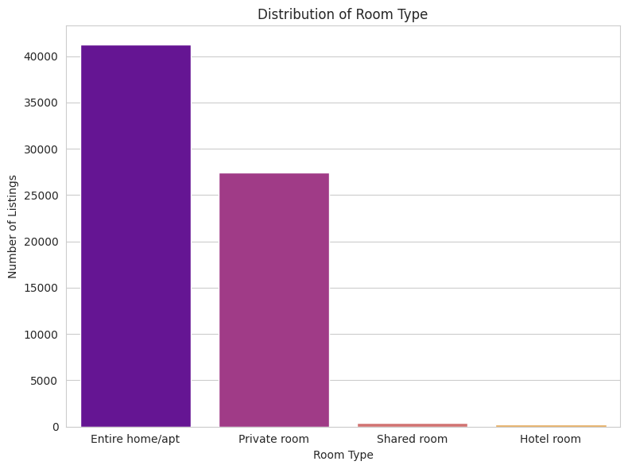

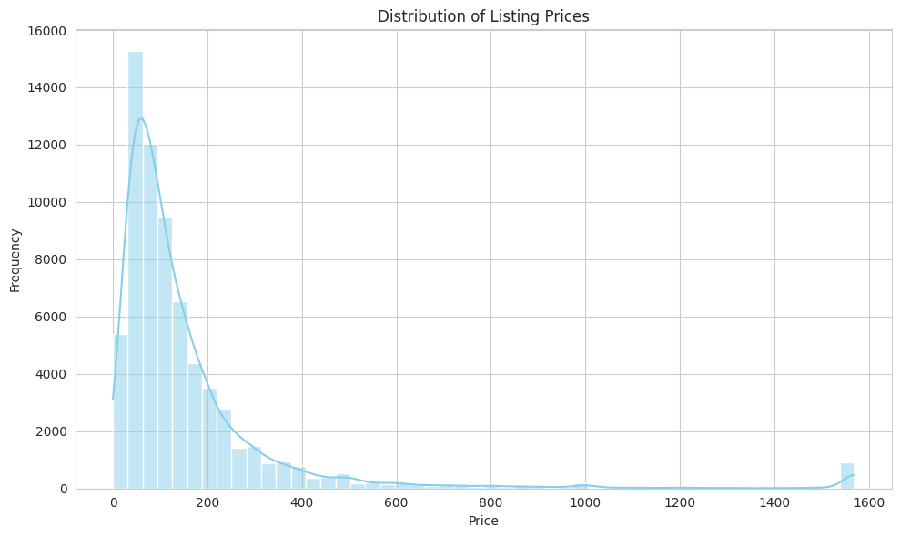

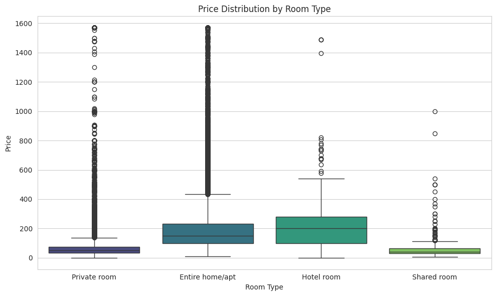

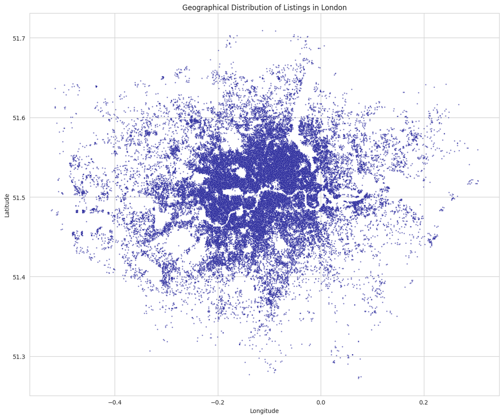

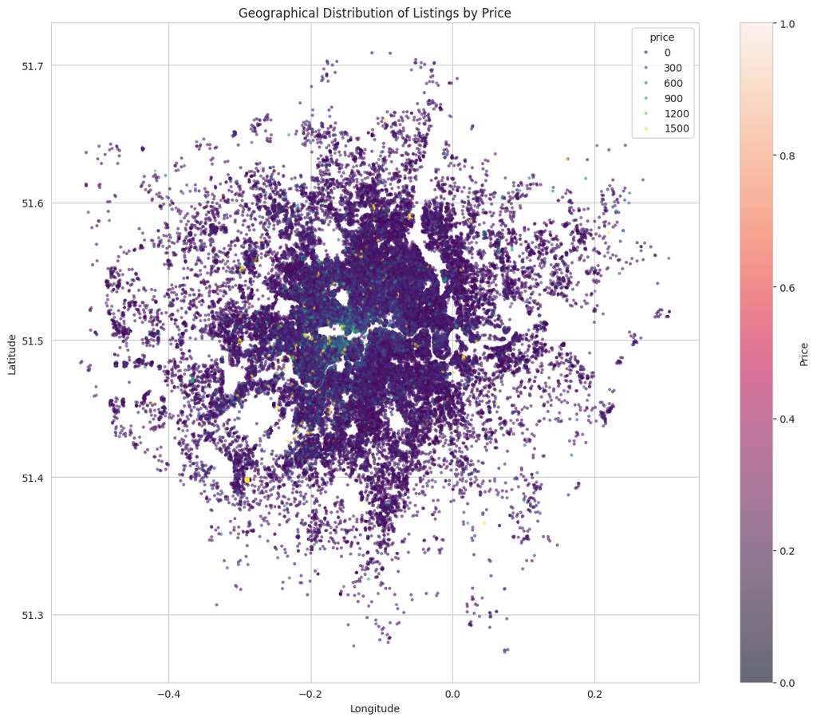

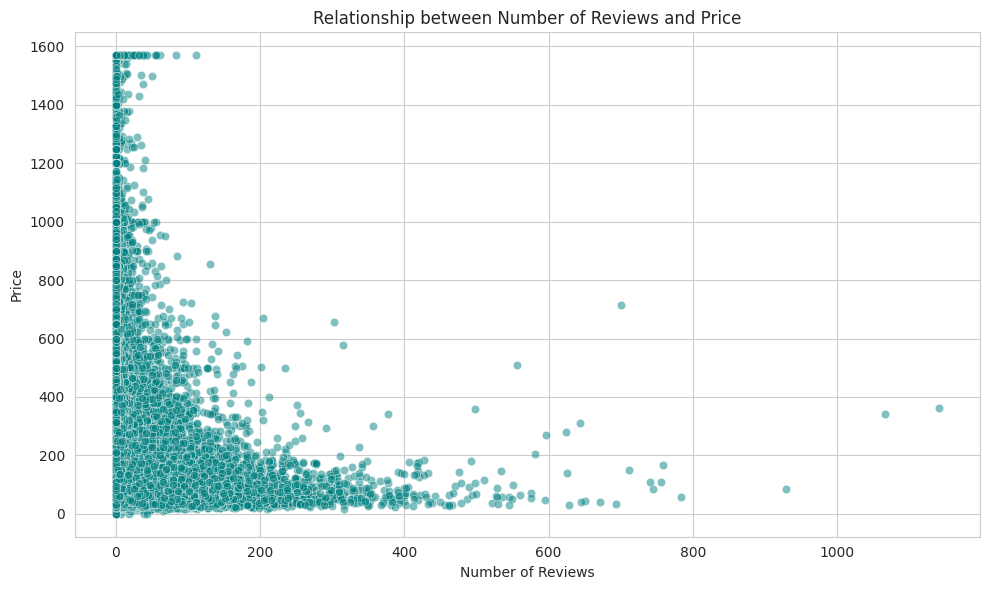

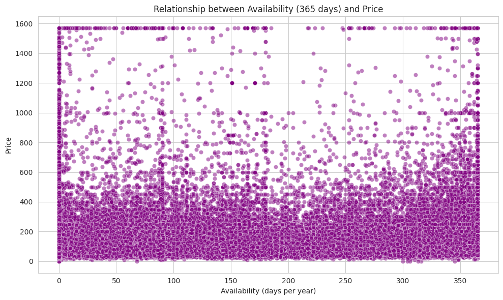

```python
import pandas as pd
import matplotlib.pyplot as plt
import seaborn as sns

sns.set_style('whitegrid')

if 'neighbourhood_group' in df.columns:
    plt.figure(figsize=(12, 6))
    sns.countplot(data=df, x='neighbourhood_group', order=df['neighbourhood_group'].value_counts().index, palette='viridis')
    plt.title('Distribution of Listings by Neighbourhood Group')
    plt.xlabel('Neighbourhood Group')
    plt.ylabel('Number of Listings')
    plt.xticks(rotation=45, ha='right')
    plt.tight_layout()
    plt.show()
else:
    print("'neighbourhood_group' column not found, skipping plot.")

if 'room_type' in df.columns:
    plt.figure(figsize=(8, 6))
    sns.countplot(data=df, x='room_type', order=df['room_type'].value_counts().index, palette='plasma')
    plt.title('Distribution of Room Type')
    plt.xlabel('Room Type')
    plt.ylabel('Number of Listings')
    plt.tight_layout()
    plt.show()
else:
    print("'room_type' column not found, skipping plot.")

if 'price' in df.columns and pd.api.types.is_numeric_dtype(df['price']):
    plt.figure(figsize=(10, 6))
    sns.histplot(data=df, x='price', bins=50, kde=True, color='skyblue')
    plt.title('Distribution of Listing Prices')
    plt.xlabel('Price')
    plt.ylabel('Frequency')
    plt.tight_layout()
    plt.show()

    if 'room_type' in df.columns:
        plt.figure(figsize=(10, 6))
        sns.boxplot(data=df, x='room_type', y='price', palette='viridis')
        plt.title('Price Distribution by Room Type')
        plt.xlabel('Room Type')
        plt.ylabel('Price')
        plt.tight_layout()
        plt.show()
    else:
        print("'room_type' column not found, skipping Price by Room Type box plot.")
else:
    print("'price' column not found or not numeric, skipping price plots.")


if 'latitude' in df.columns and 'longitude' in df.columns and pd.api.types.is_numeric_dtype(df['latitude']) and pd.api.types.is_numeric_dtype(df['longitude']):
    plt.figure(figsize=(12, 10))
    sns.scatterplot(data=df, x='longitude', y='latitude', alpha=0.5, s=5, color='darkblue')
    plt.title('Geographical Distribution of Listings in London')
    plt.xlabel('Longitude')
    plt.ylabel('Latitude')
    plt.tight_layout()
    plt.show()

    if 'price' in df.columns and pd.api.types.is_numeric_dtype(df['price']):
         plt.figure(figsize=(12, 10))


         scatterplot_plot = sns.scatterplot(data=df, x='longitude', y='latitude', hue='price', alpha=0.6, s=10, palette='viridis', linewidth=0)
         plt.title('Geographical Distribution of Listings by Price')
         plt.xlabel('Longitude')
         plt.ylabel('Latitude')


         plt.colorbar(scatterplot_plot.collections[0], label='Price')
         plt.tight_layout()
         plt.show()
    else:
        print("'price' column not found or not numeric, skipping geographical plot by price.")
else:
    print("Latitude or Longitude columns not found or not numeric, skipping geographical plots.")

if 'number_of_reviews' in df.columns and 'price' in df.columns and pd.api.types.is_numeric_dtype(df['number_of_reviews']) and pd.api.types.is_numeric_dtype(df['price']):
    plt.figure(figsize=(10, 6))
    sns.scatterplot(data=df, x='number_of_reviews', y='price', alpha=0.5, color='teal')
    plt.title('Relationship between Number of Reviews and Price')
    plt.xlabel('Number of Reviews')
    plt.ylabel('Price')
    plt.tight_layout()
    plt.show()
else:
    print("'number_of_reviews' or 'price' column not found or not numeric, skipping reviews vs price plot.")

if 'availability_365' in df.columns and 'price' in df.columns and pd.api.types.is_numeric_dtype(df['availability_365']) and pd.api.types.is_numeric_dtype(df['price']):
    plt.figure(figsize=(10, 6))
    sns.scatterplot(data=df, x='availability_365', y='price', alpha=0.5, color='purple')
    plt.title('Relationship between Availability (365 days) and Price')
    plt.xlabel('Availability (days per year)')
    plt.ylabel('Price')
    plt.tight_layout()
    plt.show()
else:
    print("'availability_365' or 'price' column not found or not numeric, skipping availability vs price plot.")
```

```python
if 'room_type' in df.columns:
  room_type_counts = df['room_type'].value_counts()
  print("\nDistribution of Room Types:")
  print(room_type_counts)
else:
  print("'room_type' column not found.")
```

```
Distribution of Room Types:
room_type
Entire home/apt    41224
Private room       27479
Shared room          404
Hotel room           244
Name: count, dtype: int64
```

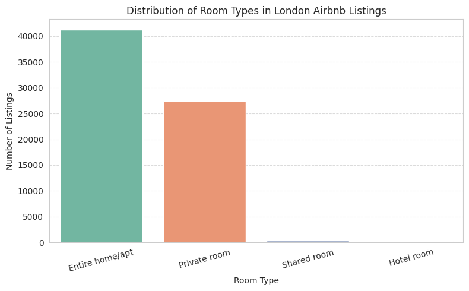

```python
plt.figure(figsize=(8, 5))
sns.countplot(data=df, x='room_type', order=df['room_type'].value_counts().index, palette='Set2')
plt.title("Distribution of Room Types in London Airbnb Listings")
plt.xlabel("Room Type")
plt.ylabel("Number of Listings")
plt.xticks(rotation=15)
plt.grid(axis='y', linestyle='--', alpha=0.7)
plt.tight_layout()
plt.show()
```

```
Top 10 Neighbourhoods by Number of Listings:
neighbourhood
Westminster               7763
Tower Hamlets             5595
Hackney                   5168
Camden                    4707
Kensington and Chelsea    4612
Southwark                 3968
Islington                 3790
Lambeth                   3719
Wandsworth                3473
Hammersmith and Fulham    2996
Name: count, dtype: int64
```

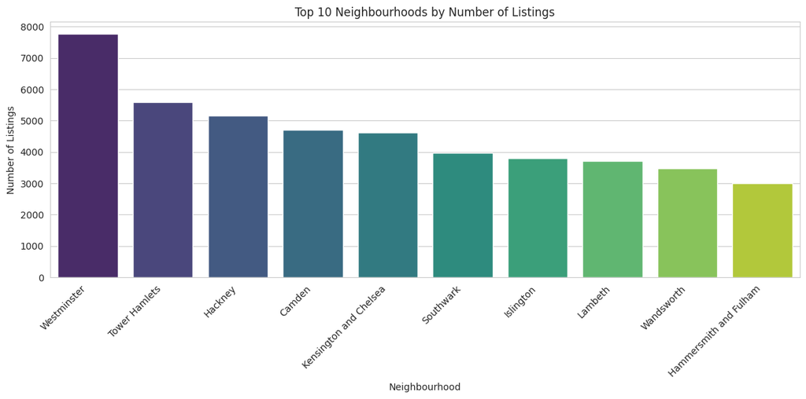

```python
import matplotlib.pyplot as plt

if 'neighbourhood' in df.columns:
  top_n_neighbourhoods = df['neighbourhood'].value_counts().nlargest(10)
  print("\nTop 10 Neighbourhoods by Number of Listings:")
  print(top_n_neighbourhoods)

  plt.figure(figsize=(12, 6))
  sns.barplot(x=top_n_neighbourhoods.index, y=top_n_neighbourhoods.values, palette='viridis')
  plt.title('Top 10 Neighbourhoods by Number of Listings')
  plt.xlabel('Neighbourhood')
  plt.ylabel('Number of Listings')
  plt.xticks(rotation=45, ha='right')
  plt.tight_layout()
  plt.show()
else:
  print("'neighbourhood' column not found, skipping Top Neighbourhoods analysis.")
```

```
Average Price by Room Type:
room_type
Hotel room         245.836066
Entire home/apt    211.722443
Private room        96.484406
Shared room         66.235149
Name: price, dtype: float64
```

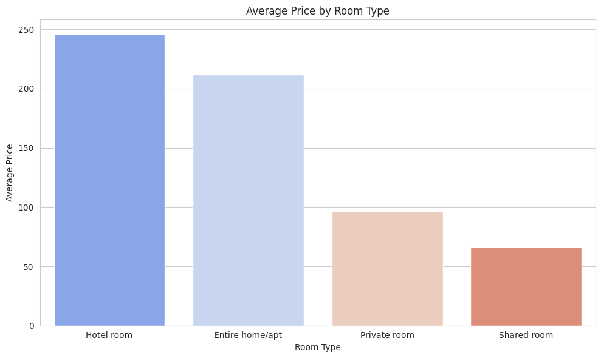

```python
import pandas as pd
import matplotlib.pyplot as plt

if 'room_type' in df.columns and 'price' in df.columns and pd.api.types.is_numeric_dtype(df['price']):
    avg_price_by_room_type = df.groupby('room_type')['price'].mean().sort_values(ascending=False)

    print("\nAverage Price by Room Type:")
    print(avg_price_by_room_type)

    plt.figure(figsize=(10, 6))
    sns.barplot(x=avg_price_by_room_type.index, y=avg_price_by_room_type.values, palette='coolwarm')
    plt.title('Average Price by Room Type')
    plt.xlabel('Room Type')
    plt.ylabel('Average Price')
    plt.xticks(rotation=0)
    plt.tight_layout()
    plt.show()
else:
    print("'room_type' or 'price' column not found or 'price' is not numeric, skipping Price by Room Type analysis.")
```

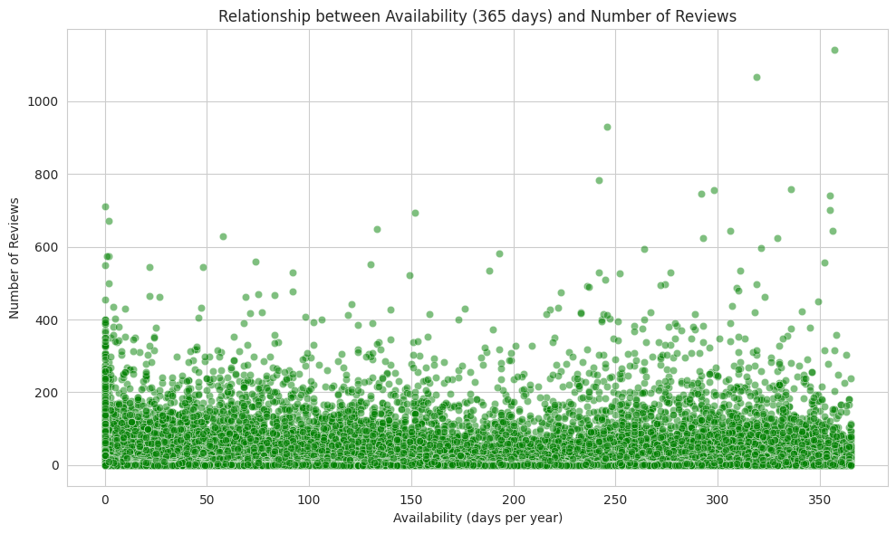

```
Average Number of Reviews by Availability Range:
availability_range
91-180     24.765201
31-90      23.145425
181-365    20.688086
0-30       12.914602
Name: number_of_reviews, dtype: float64
```

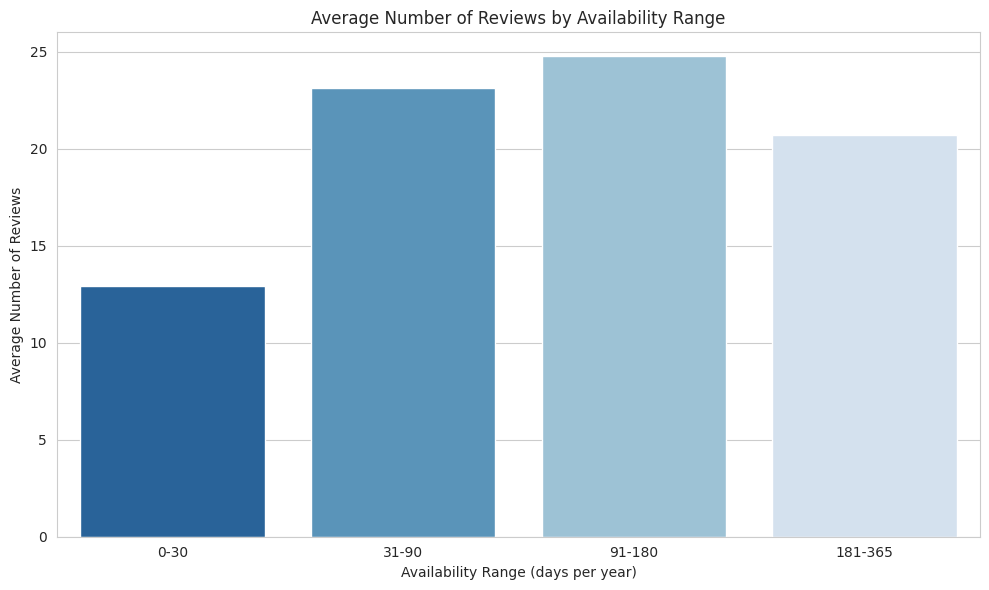

```python
import pandas as pd
import matplotlib.pyplot as plt

if 'availability_365' in df.columns and 'number_of_reviews' in df.columns and pd.api.types.is_numeric_dtype(df['availability_365']) and pd.api.types.is_numeric_dtype(df['number_of_reviews']):
    plt.figure(figsize=(10, 6))
    sns.scatterplot(data=df, x='availability_365', y='number_of_reviews', alpha=0.5, color='green')
    plt.title('Relationship between Availability (365 days) and Number of Reviews')
    plt.xlabel('Availability (days per year)')
    plt.ylabel('Number of Reviews')
    plt.tight_layout()
    plt.show()

    bins = [0, 30, 90, 180, 365]
    labels = ['0-30', '31-90', '91-180', '181-365']
    df['availability_range'] = pd.cut(df['availability_365'], bins=bins, labels=labels, right=True, include_lowest=True)

    avg_reviews_by_availability = df.groupby('availability_range')['number_of_reviews'].mean().sort_values(ascending=False)

    print("\nAverage Number of Reviews by Availability Range:")
    print(avg_reviews_by_availability)

    plt.figure(figsize=(10, 6))
    sns.barplot(x=avg_reviews_by_availability.index, y=avg_reviews_by_availability.values, palette='Blues_r')
    plt.title('Average Number of Reviews by Availability Range')
    plt.xlabel('Availability Range (days per year)')
    plt.ylabel('Average Number of Reviews')
    plt.tight_layout()
    plt.show()
else:
    print("'availability_365' or 'number_of_reviews' columns not found or not numeric, skipping availability vs reviews analysis.")
```

```
Distribution of Listings per Host:
host_id
28820321     285
33889201     266
129230780    259
314162972    189
1432477      168
Name: count, dtype: int64
count    45229.000000
mean         1.533330
std          4.003754
min          1.000000
25%          1.000000
50%          1.000000
75%          1.000000
max        285.000000
Name: count, dtype: float64
```

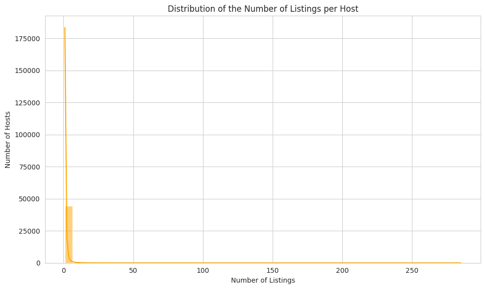

```
Number of hosts with more than 10 listings: 387
Examples of hosts with multiple listings:
host_id
28820321     285
33889201     266
129230780    259
314162972    189
1432477      168
Name: count, dtype: int64
```

```python
import matplotlib.pyplot as plt

if 'host_id' in df.columns:
    listings_per_host = df['host_id'].value_counts()

    print("\nDistribution of Listings per Host:")
    print(listings_per_host.head())
    print(listings_per_host.describe())

    plt.figure(figsize=(10, 6))
    sns.histplot(listings_per_host, bins=50, kde=True, color='orange')
    plt.title('Distribution of the Number of Listings per Host')
    plt.xlabel('Number of Listings')
    plt.ylabel('Number of Hosts')
    plt.tight_layout()
    plt.show()

    hosts_with_multiple_listings = listings_per_host[listings_per_host > 10]
    print(f"\nNumber of hosts with more than 10 listings: {len(hosts_with_multiple_listings)}")
    print("Examples of hosts with multiple listings:")
    print(hosts_with_multiple_listings.head())

else:
    print("'host_id' column not found, skipping analysis of listings per host.")
```

From the above analysis, here are the final discussions and recommendations,

Based on the exploratory data analysis, the following insights and recommendations can be drawn:

Key Findings:

a. The dataset provides a rich source of information about Airbnb listings in London, covering location, property type, pricing, availability, and review metrics.

c. Entire home/apt listings are generally priced higher than Private room or Shared room, which aligns with expectations.

d. There is a wide range in listing prices, and potential outliers were identified and handled through capping.

e. The geographical plots show the density of listings across London and provide a visual understanding of how prices are distributed geographically.

h. A significant number of hosts manage multiple listings, indicating the presence of professional hosts or property management companies on the platform.

Recommendations:

1. For Airbnb Hosts:

a. To maximize bookings and reviews, consider competitive pricing based on room type and neighbourhood.

c. Focus on providing excellent guest experiences to encourage positive reviews, which can improve listing visibility and appeal.

d. Hosts with multiple properties could analyze the performance of each listing individually to identify best practices.

2. For Airbnb as a Platform:

a. Leverage geographical data to identify underserved areas or areas with high demand for targeted marketing.

b. Implement features or guidelines to help hosts manage pricing and availability effectively.

c. Consider mechanisms to encourage reviews, especially for listings with low review counts but high availability.

d. Further investigate the activity of hosts with multiple listings to ensure compliance with platform policies and maintain a balance between individual and professional hosts.

3. For Data Scientists/Analysts:

a. Further feature engineering could involve creating metrics like 'average_reviews_per_month', 'price_per_person' (if occupancy data is available), or distance to key landmarks.

b. More sophisticated outlier detection and handling methods could be explored.

c. Machine learning models (e.g., regression models) could be built to predict optimal pricing based on listing features.

d. Time-series analysis could be applied if historical data were available to understand trends in pricing, availability, and reviews.

e. Cluster analysis could be used to group similar listings or neighbourhoods for targeted strategies.

Limitations:

a. The analysis is based on a snapshot of the data at a specific point in time and does not capture temporal trends.

b. Missing values were handled using simple methods (filling with 0 or a placeholder); more advanced imputation techniques might be beneficial.

c. The definition and boundaries of 'neighbourhood' might require further clarification for more precise geographical analysis.

d. External factors like seasonality, local events, and economic conditions were not included in this analysis but could significantly impact listing performance.

Future Work:

a. Incorporate external datasets, such as demographic data, tourist attractions, public transport access, and local event calendars.

b. Develop predictive models for pricing, occupancy, or review generation.

c. Conduct A/B testing on different pricing strategies or listing features.

d. Perform sentiment analysis on review text to understand guest satisfaction drivers.

e. Build interactive dashboards to visualize key metrics and trends.